# Wangling and Analyze Data

## Introduction

In this project, the dataset 'WeRateDogs' will be wrangled (and as well analyzed and visualized). WeRateDogs is a Twitter account that rates people's dogs with a humorous comment about the dog. These ratings almost always have a denominator of 10. The account has over four (4) million followers and has received international media coverage. Because real-world data rarely comes clean, data will thus be gathered (based on WeRateDogs) from a variety of sources with the end goal of analyzing and visualizing the collated information afterwards.

The Wrangling will follow this format:

1. Data Gathering
2. Assessing the Data
3. Cleaning the Data

The jupyter notebook **[GERARD NONSO OBIORA PROJECT TWO WORK (wrangle_act)]** has the project code and the aim here is to communicate the insights and show the visualizations produced from my wrangled data.

# Questions Posed

1. Which breed of dog was more than others by count?
2. What is the most popular (that is, used) name (actual name) given to a dog?And list the breeds of dog such name was given to.
3. State the most reoccurring dog stage that is not 'None'.

# Analysis and Visualizations

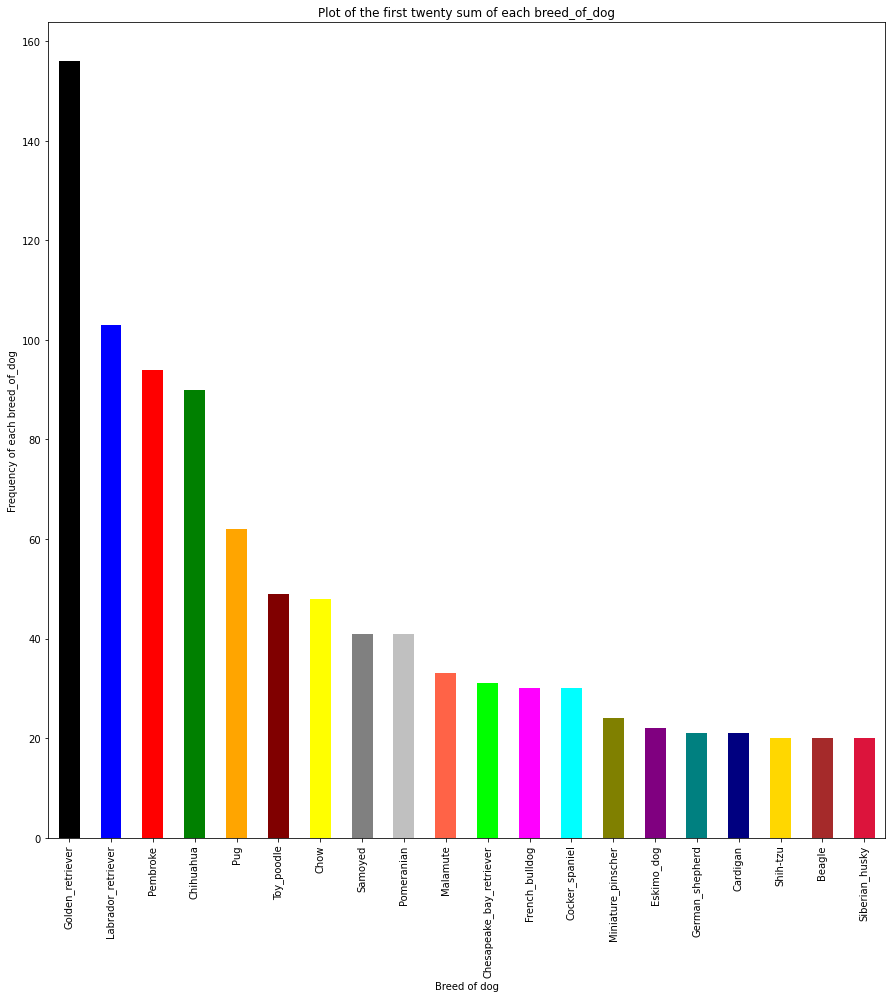

#### Insight 1:

The breed of dog with the highest count is 'golden_retriever'.

[figure not shown]

#### Insight 2:

The name mostly given to a dog is 'Cooper'. And the dog breeds it was given to includes:

1. whippet
2. dalmatian
3. Labrador_retriever
4. Pekinese
5. bluetick
6. Labrador_retriever
7. Norwich_terrier
8. Great_Pyrenees
9. golden_retriever
10. malamute

[figure not shown]

# Conclusions

The wrangle data shows that the dog breed 'golden_retriever' was highest by count.And 'Cooper' was a popular dog name given to the various dog breeds while the dog stage 'pupper'was the the most reoccurring amongst the breeds of dog.